# Homework 1

Mari Sanders

2024-09-13

# Problem 1

1. Qualitative, ordinal
2. Qualitative, binary
3. Qualitative, nominal
4. Quantitative, continuous
5. Quantitative, discrete

# Problem 2

```r
depression_score <- c(45,39,25,47,49,5,70,99,74,37,99,35,8,59)
```

Mean: $\frac{45 +39+25+47+49,5+70+99+74+37+99+35+8+59}{14}$ = 49.3571429

Median: 5, 8, 25, 35, 37, 39, 45, 47, 49, 59, 70, 74, 99, 99

The middle number is 46

Variance: $\frac{1}{14 -1} \sum^{12}_{i=1} (x_i - 49.35$^2) = 832.0934066

Standard Deviation: $\sqrt(832.0934) =$ 28.8460293

Range: The numbers range from 5 to 99

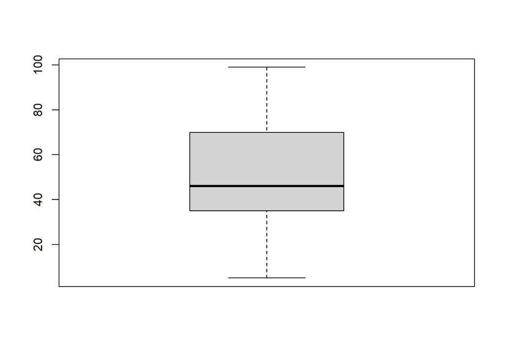

```
##      [,1]
## [1,]    5
## [2,]   35
## [3,]   46
## [4,]   70
## [5,]   99
```

```r
boxplot(depression_score)$stats
```

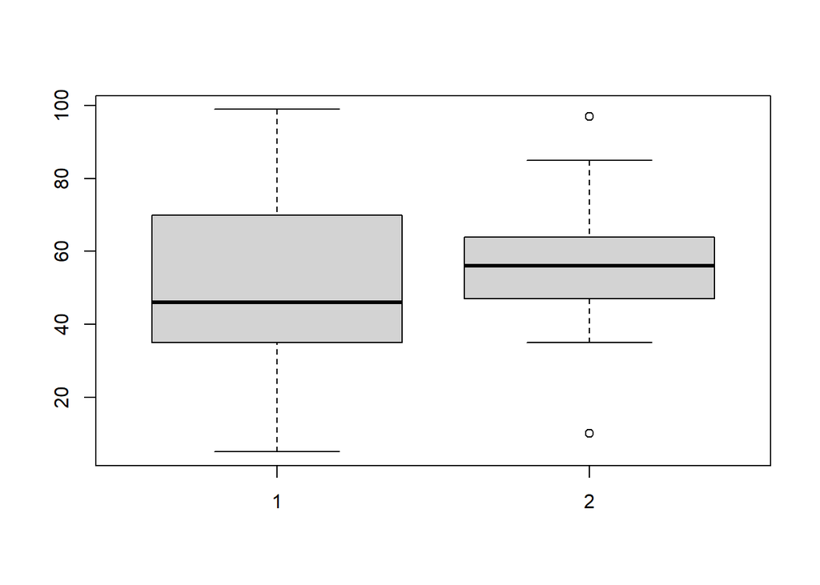

```
##      [,1] [,2]
## [1,]    5   35
## [2,]   35   47
## [3,]   46   56
## [4,]   70   64
## [5,]   99   85
```

```r
depression_score_car <- c(67, 50, 85, 43, 64, 35, 47, 97, 58, 58, 10, 56, 50)

boxplot(depression_score, depression_score_car)$stats
```

2. The first boxplot is right skewed, with a median of 46, a minimum of 5, an IQR = $70-35 = 35$ and a max of 99. The second boxplot is fairly symmetric, with a minimum of 35, and IQR = $64-47) = 17$, a median of 56, and a max of 85. There also seem to be some outliers in this second boxplot.
3. The first group, the individuals from a bike crash seem to have lower depression score than the second group, the individuals from car crashes. This is because the median is lower in the first than the second.

# Problem 3

1. P(even number) = $\frac{6}{12} = \frac{1}{2}$
2. P(number 10 appears) = $\frac{1}{12}$
3. $P( A \cup B) = P(A) + P(B) - P(A \cap B)$ $P(A \cap B) = \frac{1}{12}$ because when there is 1 chance where an even number appears and a 10 appears.

$$P(A \cup B) = \frac{1}{2} + \frac{1}{12}
- \frac{1}{12} = \frac{1}{2}$$

4. No the events are not independent. If they were, $P(A \cap B) = 0$, but we found that it in fact equals to $\frac{1}{12}$. Since $P(A \cap B) \neq 0$, events A and B are not independent.

# Problem 4

Want to find the probability that the woman has dementia given that she has a positive test. Given $P(P|D)$ = 0.80 and $P(P|D^c) = 0.10$, and P(D) = 0.05

$P(P) = P(P|D) \cdot P(D) + P(P|D^c) \cdot P(D^c)$

$P(P) = (0.80)(0.05) + (0.1)(1-0.05) = 0.135$

Now we want to find the P(D|P)

P(D|P) = $\frac{P(D \cap P) \cdot P(D)}{P(P)} = \frac{0.80 \cdot 0.05}{0.135}$

$$P(D|P) = 0.296$$